# PASO 6 y 7

# Paso 6. Posteriores y matriz de dominancia en la ventana operativa

En el paso anterior se vio que **M3 colapsa progresivamente desde el mes 13**, mientras los otros cuatro modelos mantuvieron un rendimiento estable. A partir del mes 16 el nuevo escenario se estabiliza: los estafadores consolidaron su modus operandi y con ello los modelos encontraron un nuevo piso de performance.

Este paso construye tres objetos sobre esa **ventana operativa (meses 16 a 18)**:

1. **Posteriores Beta-Binomial agregadas** por modelo — mediana y HPDI 95%.
2. **Densidades posteriores de F1** superpuestas — para visualizar solapamiento.
3. **Matriz de dominancia 5×5** — P(F1ᵢ > F1ⱼ) para cada par de modelos.

**Supuesto de persistencia declarado:** la decisión de julio 2025 se sostiene bajo el supuesto de que el régimen post-estabilización (meses 16–18) es representativo del período siguiente. Si la campaña de phishing fuera transitoria, la ventana correcta podría ser otra. Esta elección es metodológica y se argumenta en la presentación.

## Setup

```r
library(data.table)
library(ggplot2)
library(kableExtra)

# Semilla oficial del caso
set.seed(20260424)

# Tamaño de muestra Monte Carlo (se pidió un mínimo de 5000, en este caso usé 10000 que debería tener el mismo o parecido resultado)
S <- 10000

# Crear carpetas de salida
dir.create("reports/tables",  recursive = TRUE, showWarnings = FALSE)
dir.create("reports/figures", recursive = TRUE, showWarnings = FALSE)
```

```r
MODELOS <- c("M1_logistica", "M2_random_forest", "M3_gbm_completo",
             "M4_gbm_moderado", "M5_naive_bayes")

LABELS  <- c("M1 Logistica", "M2 Random Forest", "M3 GBM Completo",
             "M4 GBM Moderado", "M5 Naive Bayes")

COLORES <- c(
  "M1_logistica"     = "#4878CF",
  "M2_random_forest" = "#6ACC65",
  "M3_gbm_completo"  = "#D65F5F",
  "M4_gbm_moderado"  = "#B47CC7",
  "M5_naive_bayes"   = "#C4AD66"
)
```

## 1. Conteos agregados sobre la ventana operativa

### 1.1 Carga y filtrado

```r
df_temp <- fread("data/raw/metricas_temporales.csv")

# Filtrar únicamente los meses 16, 17 y 18
df_op <- df_temp[mes >= 16 & mes <= 18]

cat("Filas en la ventana operativa:", nrow(df_op), "\n")
```

```
## Filas en la ventana operativa: 15
```

```r
cat("Modelos:", unique(df_op$modelo), "\n")
```

```
## Modelos: M1_logistica M2_random_forest M3_gbm_completo M4_gbm_moderado M5_naive_bayes
```

```r
cat("Meses:  ", unique(df_op$mes), "\n")
```

```
## Meses:   16 17 18
```

### 1.2 Reconstrucción de TP, FP, FN

```r
df_op[, tp := round(recall * n_fraude)]
df_op[, fn := n_fraude - tp]
df_op[, fp := ifelse(precision > 0, round((tp / precision) - tp), 0L)]
```

### 1.3 Agregación sobre los tres meses

```r
# Nota: los conteos agregados sobre los tres meses acumulan más evidencia que cualquier mes individual, lo que produce posteriores más concentradas (HPDI más angosto).

conteos_op <- df_op[, .(
  TP = sum(tp),
  FP = sum(fp),
  FN = sum(fn)
), by = modelo]

# Mostrar tabla de conteos
conteos_op |>
  kable(
    caption = "Conteos agregados por modelo — ventana operativa meses 16–18",
    col.names = c("Modelo", "TP", "FP", "FN")
  ) |>
  kable_styling(bootstrap_options = c("striped", "hover"), full_width = FALSE)
```

Conteos agregados por modelo — ventana operativa meses 16–18

| Modelo | TP | FP | FN |
| --- | --- | --- | --- |
| M1_logistica | 123 | 245 | 419 |
| M2_random_forest | 153 | 290 | 389 |
| M3_gbm_completo | 32 | 51 | 510 |
| M4_gbm_moderado | 167 | 332 | 375 |
| M5_naive_bayes | 111 | 327 | 431 |

## 2. Posteriores Beta-Binomial y propagación Monte Carlo

**Supuesto de independencia:** precisión y recall se estiman a partir de conteos disjuntos (TP/FP vs. TP/FN). Aunque TP aparece en ambos denominadores, las posteriores marginales son aproximadamente independientes. Este supuesto puede subestimar la incertidumbre conjunta si los errores están correlacionados.

### 2.1 Simulación

```r
muestras_lista <- list()

for (mod in MODELOS) {
  fila <- conteos_op[modelo == mod]
  tp   <- fila$TP
  fp   <- fila$FP
  fn   <- fila$FN

  # Posteriores conjugadas Beta-Binomial
  muestras_p <- rbeta(S, shape1 = 1 + tp, shape2 = 1 + fp)
  muestras_r <- rbeta(S, shape1 = 1 + tp, shape2 = 1 + fn)

  # Propagación a F1
  muestras_f1 <- (2 * muestras_p * muestras_r) / (muestras_p + muestras_r)

  muestras_lista[[mod]] <- muestras_f1
}

cat("Simulación completada:", S, "muestras por modelo\n")
```

```
## Simulación completada: 10000 muestras por modelo
```

### 2.2 Tabla resumen: mediana + HPDI 95%

```r
resumen_op <- rbindlist(lapply(MODELOS, function(mod) {
  f1s    <- muestras_lista[[mod]]
  fila_c <- conteos_op[modelo == mod]
  data.table(
    Modelo     = mod,
    TP         = fila_c$TP,
    FP         = fila_c$FP,
    FN         = fila_c$FN,
    Mediana_F1 = round(median(f1s), 3),
    HPDI_lo    = round(quantile(f1s, 0.025), 3),
    HPDI_hi    = round(quantile(f1s, 0.975), 3)
  )
}))

# Ordenar por mediana descendente
resumen_op <- resumen_op[order(-Mediana_F1)]

# Mostrar tabla
resumen_op[, .(
  Modelo,
  Conteos    = paste0("TP:", TP, " / FP:", FP, " / FN:", FN),
  Mediana_F1,
  HPDI_95    = paste0("[", HPDI_lo, ", ", HPDI_hi, "]")
)] |>
  kable(
    col.names = c("Modelo", "Conteos", "Mediana F1", "HPDI 95%")
  ) |>
  kable_styling(bootstrap_options = c("striped", "hover"), full_width = FALSE) |>
  row_spec(1, bold = TRUE, background = "#e8f4e8") |>   # se destaca modelo ganador
  row_spec(5, bold = TRUE, background = "#fde8e8")       # destaca modelo colapsado
```

| Modelo | Conteos | Mediana F1 | HPDI 95% |
| --- | --- | --- | --- |
| M4_gbm_moderado | TP:167 / FP:332 / FN:375 | 0.321 | [0.292, 0.349] |
| M2_random_forest | TP:153 / FP:290 / FN:389 | 0.311 | [0.282, 0.34] |
| M1_logistica | TP:123 / FP:245 / FN:419 | 0.271 | [0.242, 0.301] |
| M5_naive_bayes | TP:111 / FP:327 / FN:431 | 0.227 | [0.201, 0.253] |
| M3_gbm_completo | TP:32 / FP:51 / FN:510 | 0.104 | [0.076, 0.135] |

```r
# Guardar
fwrite(
  resumen_op[, .(Modelo, TP, FP, FN, Mediana_F1,
                 HPDI_95 = paste0("[", HPDI_lo, ", ", HPDI_hi, "]"))],
  "reports/tables/paso6_resumen_ventana_operativa.csv"
)
```

> M4 lidera con mediana 0.321 (HPDI: [0.292, 0.349]). M3 colapsó a una mediana de 0.104.

## 3. Densidades posteriores superpuestas

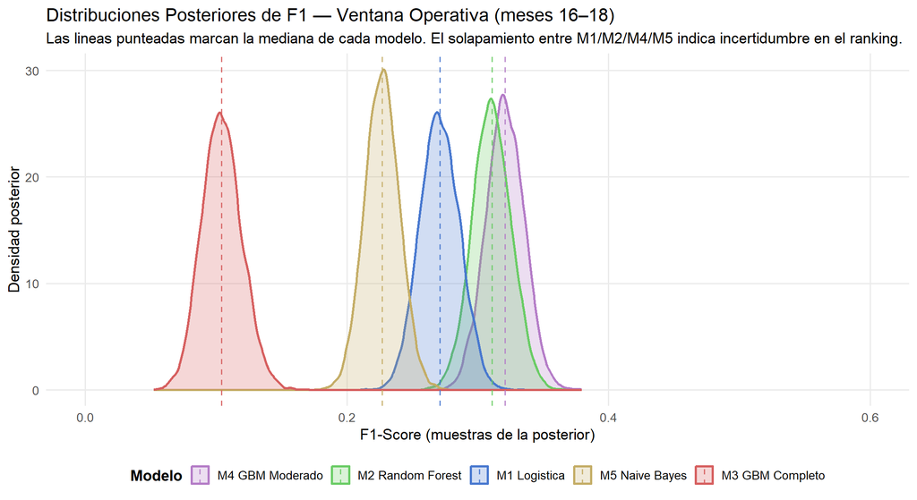

```r
# Armar data.table largo
dt_densidades <- rbindlist(lapply(MODELOS, function(mod) {
  data.table(modelo = mod, F1 = muestras_lista[[mod]])
}))

# Factor ordenado por mediana (leyenda de mayor a menor)
dt_densidades[, modelo := factor(modelo, levels = resumen_op$Modelo)]

# Medianas para lineas verticales
dt_med <- resumen_op[, .(modelo = Modelo, med = Mediana_F1)]

fig_densidades <- ggplot(dt_densidades,
                         aes(x = F1, fill = modelo, color = modelo)) +
  geom_density(alpha = 0.25, linewidth = 0.9) +
  geom_vline(
    data     = dt_med,
    aes(xintercept = med, color = modelo),
    linetype = "dashed", linewidth = 0.7, alpha = 0.85
  ) +
  scale_fill_manual(values = COLORES, labels = setNames(LABELS, MODELOS)) +
  scale_color_manual(values = COLORES, labels = setNames(LABELS, MODELOS)) +
  coord_cartesian(xlim = c(0, 0.6)) +
  labs(
    title    = "Distribuciones Posteriores de F1 — Ventana Operativa (meses 16–18)",
    subtitle = paste0(
      "Las lineas punteadas marcan la mediana de cada modelo. ",
      "El solapamiento entre M1/M2/M4/M5 indica incertidumbre en el ranking."
    ),
    x     = "F1-Score (muestras de la posterior)",
    y     = "Densidad posterior",
    fill  = "Modelo",
    color = "Modelo"
  ) +
  theme_minimal(base_size = 13) +
  theme(
    panel.grid.minor = element_blank(),
    legend.position  = "bottom",
    legend.title     = element_text(face = "bold")
  )

fig_densidades
```

```r
ggsave("reports/figures/punto6_densidades_operativa.png",
       plot = fig_densidades, width = 11, height = 6, dpi = 300)
```

> **Interpretación:**
> - **M3** (rojo) está completamente separado a la izquierda — su posterior no se solapa con ningún otro modelo. Su colapso es evidente.
> - **M4** (violeta) tiene la mediana más alta pero su densidad **se solapa parcialmente** con M1 y M2. Esto significa que la dominancia de M4 no es absoluta contra todos los rivales — se cuantifica en la matriz del siguiente punto.
> - El solapamiento entre M1/M2/M4/M5 justifica el uso de la matriz de dominancia en lugar de un simple ranking por mediana.

## 4. Robustez ≠ rendimiento

Antes de construir la matriz de dominancia, aclaramos la diferencia entre buscar mayor robustez vs obtener mayor rendimiento:

```r
# Calcular varianza temporal de F1 por modelo en T1 (meses 13-18)
df_t1 <- df_temp[mes >= 13 & mes <= 18]
df_t1[, tp := round(recall * n_fraude)]
df_t1[, fn := n_fraude - tp]
df_t1[, fp := ifelse(precision > 0, round((tp / precision) - tp), 0L)]
df_t1[, f1_puntual := 2 * tp / (2 * tp + fp + fn)]

varianza_t1 <- df_t1[, .(
  F1_media  = round(mean(f1_puntual, na.rm = TRUE), 3),
  F1_desvio = round(sd(f1_puntual,   na.rm = TRUE), 3)
), by = modelo][order(-F1_media)]

varianza_t1 |>
  kable(
    caption = "Variabilidad temporal de F1 en T1 (meses 13–18)",
    col.names = c("Modelo", "F1 media en T1", "Desvio estandar temporal")
  ) |>
  kable_styling(bootstrap_options = c("striped", "hover"), full_width = FALSE)
```

Variabilidad temporal de F1 en T1 (meses 13–18)

| Modelo | F1 media en T1 | Desvio estandar temporal |
| --- | --- | --- |
| M3_gbm_completo | 0.335 | 0.275 |
| M4_gbm_moderado | 0.306 | 0.049 |
| M2_random_forest | 0.304 | 0.048 |
| M1_logistica | 0.279 | 0.041 |
| M5_naive_bayes | 0.224 | 0.043 |

> **Conclusión:** M1 y M5 tienen bajo desvío temporal en T1 — son “estables”. Sin embargo, esa estabilidad refleja un **F1 bajo y constante**, no un buen rendimiento. Un modelo estable pero dominado en la matriz no es una alternativa válida para producción. **Robustez temporal no es sinónimo de rendimiento superior.**

## 5. Matriz de dominancia 5×5

### 5.1 Construcción

```r
n   <- length(MODELOS)
mat <- matrix(0, nrow = n, ncol = n,
              dimnames = list(MODELOS, MODELOS))

for (i in seq_len(n)) {
  for (j in seq_len(n)) {
    if (i == j) {
      mat[i, j] <- 0.5   # un modelo vs. sí mismo = 50%
    } else {
      mat[i, j] <- mean(
        muestras_lista[[MODELOS[i]]] > muestras_lista[[MODELOS[j]]]
      )
    }
  }
}

# Mostrar matriz redondeada
round(mat, 3) |>
  kable(caption = "Matriz de dominancia P(F1_i > F1_j) — ventana operativa meses 16–18") |>
  kable_styling(bootstrap_options = c("striped", "hover"), full_width = FALSE)
```

Matriz de dominancia P(F1_i > F1_j) — ventana operativa meses 16–18

|  | M1_logistica | M2_random_forest | M3_gbm_completo | M4_gbm_moderado | M5_naive_bayes |
| --- | --- | --- | --- | --- | --- |
| M1_logistica | 0.500 | 0.030 | 1.0 | 0.010 | 0.986 |
| M2_random_forest | 0.970 | 0.500 | 1.0 | 0.313 | 1.000 |
| M3_gbm_completo | 0.000 | 0.000 | 0.5 | 0.000 | 0.000 |
| M4_gbm_moderado | 0.990 | 0.687 | 1.0 | 0.500 | 1.000 |
| M5_naive_bayes | 0.014 | 0.000 | 1.0 | 0.000 | 0.500 |

```r
# Guardar
dt_mat <- as.data.table(mat, keep.rownames = "Modelo_i")
fwrite(dt_mat, "reports/tables/paso6_matriz_dominancia.csv")
```

**Supuesto de independencia entre modelos:** los cinco modelos comparten los mismos datos de validación, por lo que sus errores pueden estar correlacionados. Estimar P(F1ᵢ > F1ⱼ) asumiendo independencia entre las muestras puede **subestimar la incertidumbre conjunta**. Este supuesto se declara y se discute en la presentación.

### 5.2 Heatmap

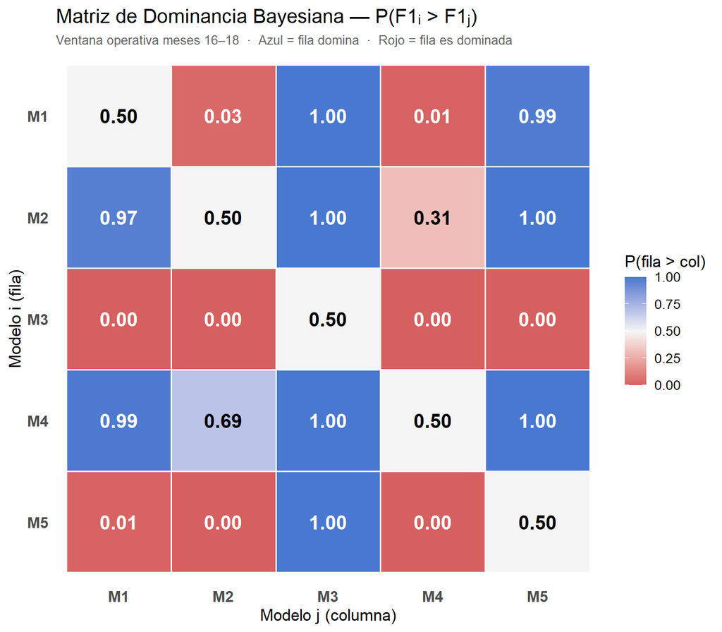

```r
etiquetas_cortas <- c(
  "M1_logistica"     = "M1",
  "M2_random_forest" = "M2",
  "M3_gbm_completo"  = "M3",
  "M4_gbm_moderado"  = "M4",
  "M5_naive_bayes"   = "M5"
)

dt_heatmap      <- as.data.table(mat, keep.rownames = "Modelo_i")
dt_heatmap_long <- melt(dt_heatmap,
                        id.vars       = "Modelo_i",
                        variable.name = "Modelo_j",
                        value.name    = "Prob")

dt_heatmap_long[, Modelo_i := factor(
  etiquetas_cortas[Modelo_i],
  levels = rev(c("M1","M2","M3","M4","M5"))
)]
dt_heatmap_long[, Modelo_j := factor(
  etiquetas_cortas[as.character(Modelo_j)],
  levels = c("M1","M2","M3","M4","M5")
)]
dt_heatmap_long[, color_texto := ifelse(Prob > 0.25 & Prob < 0.75, "black", "white")]

fig_heatmap <- ggplot(dt_heatmap_long,
                      aes(x = Modelo_j, y = Modelo_i, fill = Prob)) +
  geom_tile(color = "white", linewidth = 0.6) +
  geom_text(aes(label = sprintf("%.2f", Prob), color = color_texto),
            size = 5.5, fontface = "bold") +
  scale_fill_gradient2(
    low      = "#D65F5F",
    mid      = "#F5F5F5",
    high     = "#4878CF",
    midpoint = 0.5,
    limits   = c(0, 1),
    name     = "P(fila > col)"
  ) +
  scale_color_identity() +
  labs(
    title    = "Matriz de Dominancia Bayesiana — P(F1ᵢ > F1ⱼ)",
    subtitle = "Ventana operativa meses 16–18  ·  Azul = fila domina  ·  Rojo = fila es dominada",
    x = "Modelo j (columna)",
    y = "Modelo i (fila)"
  ) +
  theme_minimal(base_size = 13) +
  theme(
    panel.grid      = element_blank(),
    axis.text       = element_text(face = "bold", size = 12),
    legend.position = "right",
    plot.subtitle   = element_text(size = 10, color = "grey40")
  )

fig_heatmap
```

```r
ggsave("reports/figures/punto_6_matriz_dominancia.png",
       plot = fig_heatmap, width = 8, height = 7, dpi = 300)
```

### 5.3 Lectura de la matriz

```r
ganador  <- resumen_op$Modelo[1]
rivals   <- MODELOS[MODELOS != ganador]

cat("=== Dominancia del modelo recomendado ===\n\n")
```

```
## === Dominancia del modelo recomendado ===
```

```r
cat(sprintf("Modelo ganador en ventana operativa: %s\n\n", ganador))
```

```
## Modelo ganador en ventana operativa: M4_gbm_moderado
```

```r
for (r in rivals) {
  prob <- mat[ganador, r]
  interpretacion <- dplyr::case_when(
    prob >= 0.95 ~ "dominancia casi total",
    prob >= 0.75 ~ "dominancia clara",
    prob >= 0.55 ~ "leve ventaja",
    TRUE         ~ "empate técnico"
  )
  cat(sprintf("  P(%s > %s) = %.3f  [%s]\n", ganador, r, prob, interpretacion))
}
```

```
##   P(M4_gbm_moderado > M1_logistica) = 0.990  [dominancia casi total]
##   P(M4_gbm_moderado > M2_random_forest) = 0.687  [leve ventaja]
##   P(M4_gbm_moderado > M3_gbm_completo) = 1.000  [dominancia casi total]
##   P(M4_gbm_moderado > M5_naive_bayes) = 1.000  [dominancia casi total]
```

## 6. Supuesto de persistencia

**Ventana elegida para la decisión:** meses 16 a 18

**Supuesto declarado:**

> El régimen post-estabilización (meses 16-18) es representativo del período julio 2025 en adelante.

**Límite del supuesto:**

> Si la campaña de phishing fuera transitoria y los estafadores volvieran al modus operandi anterior, la ventana correcta podría ser T0 o una combinación. La decisión se reevalúa con nueva evidencia.

## 7. Resumen

```r
med_ganador  <- resumen_op$Mediana_F1[1]
hpdi_lo      <- resumen_op$HPDI_lo[1]
hpdi_hi      <- resumen_op$HPDI_hi[1]
prob_vs_m3   <- round(mat[ganador, "M3_gbm_completo"], 3)
med_m3       <- resumen_op[Modelo == "M3_gbm_completo", Mediana_F1]
caida        <- round(0.841 - med_m3, 3)
```

**Modelo recomendado:** M4_gbm_moderado

**Mediana F1:** 0.321 · **HPDI 95%:** [0.292, 0.349]

**P(ganador > M3):** 1

**Caida de M3 vs T0:** 0.841 → 0.104 (Delta = 0.737)

**Tres hallazgos clave:**

1. M3 colapso — su posterior en meses 16-18 no se solapa con ningun otro modelo. La dominancia de los rivales es casi total (P > 0.99).
2. M4 lidera en la ventana operativa pero su ventaja sobre M1 y M2 no es absoluta — hay solapamiento de densidades.
3. Robustez no es rendimiento — M1 y M5 son estables pero dominados por M4 en la matriz.

## Archivos generados

[output not shown]

# Paso 7. Variable comprometida y recomendacion al APFLA

## 1. Variable comprometida: terminal_risk_score

A fines de 2024 los reportes de inteligencia operativa documentaron una campana masiva de smishing dirigida a clientes del banco. El nuevo modus operandi tiene una caracteristica que lo distingue del fraude tradicional: Los estafadores utilizan credenciales robadas via SMS para operar desde terminales POS legitimas y sin historial de fraude previo.

Esto es muy distinto al patron anterior, donde el fraude se concentraba en terminales comprometidas o de alto riesgo historico.

### 1.1 Features de los modelos

```r
# Tabla de features — construida a partir de "metricas_T0_validacion.json"
dt_features <- data.table(
  Modelo   = c("M1 Logistica", "M2 Random Forest", "M3 GBM Completo",
               "M4 GBM Moderado", "M5 Naive Bayes"),
  Features = c(
    "monto_log, canal, dispositivo",
    "monto_log, secuencia_24h, canal, dispositivo, hora_bin",
    "monto_log, secuencia_24h, **terminal_risk_score**, canal, dispositivo, hora_bin",
    "monto_log, secuencia_24h, canal, dispositivo, hora_bin",
    "monto_log, secuencia_24h"
  ),
  Usa_TRS = c("No", "No", "**SI — exclusivo**", "No", "No")
)

dt_features |>
  kable(
    caption  = "Features por modelo — fuente: metricas_T0_validacion.json",
    col.names = c("Modelo", "Variables de entrada", "terminal_risk_score"),
    escape   = FALSE
  ) |>
  kable_styling(bootstrap_options = c("striped", "hover"), full_width = FALSE) |>
  row_spec(3, bold = TRUE, background = "#fde8e8")
```

Features por modelo — fuente: metricas_T0_validacion.json

| Modelo | Variables de entrada | terminal_risk_score |
| --- | --- | --- |
| M1 Logistica | monto_log, canal, dispositivo | No |
| M2 Random Forest | monto_log, secuencia_24h, canal, dispositivo, hora_bin | No |
| M3 GBM Completo | monto_log, secuencia_24h, **terminal_risk_score**, canal, dispositivo, hora_bin | **SI — exclusivo** |
| M4 GBM Moderado | monto_log, secuencia_24h, canal, dispositivo, hora_bin | No |
| M5 Naive Bayes | monto_log, secuencia_24h | No |

**`terminal_risk_score`** es la unica variable exclusiva de M3. Esta variable:

- Se construye con el historial acumulado de la terminal POS en los ultimos 90 dias
- Asigna score bajo a terminales con comportamiento historico limpio
- Era el principal discriminador de M3 — la razon de su F1 = 0.841 en T0

### 1.2 Mecanismo causal del colapso

I. En 2024 los estafadores enviaron SMS fraudulentos haciéndose pasar por el banco y obtuvieron usuario, contraseña y PIN de clientes reales. Con eso podían operar como si fueran el cliente legítimo.

II. El fraude tradicional usaba terminales comprometidas, cajeros trucados, comercios cómplices. El nuevo modus operandi no necesita eso: con las credenciales del cliente, el estafador puede operar desde cualquier terminal legítima y sin antecedentes.

III. **`terminal_risk_score`** resume el historial de fraude de una terminal en los últimos 90 días. Una terminal limpia tiene score bajo. Antes del smishing el modelo lo tomaba como terminal segura. Después del smishing la terminal deja de ser segura pero M3 no lo sabe porque fue entrenado con la lógica anterior.

IV. Cuando llega una transacción desde una terminal con score bajo, M3 asume que la terminal es limpia o sea con riesgo bajo y no supera el umbral de clasificación. Al no disparar ningún alerta, el fraude pasa desapercibido.

V. Cada fraude que pasa sin alerta es un Falso Negativo. Con el smishing masivo, los FN aumentan. Recall (TP / (TP + FN)) , cae con FN aumentando. Como F1 = 2PR/(P+R), si Recall tiende a 0 entonces F1 también.

VI. Los modelos M1, M2, M4 y M5 no usan **`terminal_risk_score`**. Sus features capturan el comportamiento transaccional (canal, dispositivo, hora, monto, secuencia) que detecta el patron anomalo del nuevo modus operandi independientemente del historial de la terminal. Por eso se mantienen estables en T1.

```r
# Usa resumen_op del Paso 6 — no recalcula nada
data.table(
  Ventana  = c("T0 (meses 1-12)", "Ventana operativa (meses 16-18)"),
  M3_F1    = c(0.841,
               round(resumen_op[Modelo == "M3_gbm_completo", Mediana_F1], 3)),
  M4_F1    = c(0.236,
               round(resumen_op[Modelo == "M4_gbm_moderado",  Mediana_F1], 3)),
  Caida_M3 = c("-",
               as.character(round(0.841 -
                 resumen_op[Modelo == "M3_gbm_completo", Mediana_F1], 3)))
) |>
  kable(
    caption   = "Caida de F1: M3 vs M4 entre T0 y ventana operativa",
    col.names = c("Ventana", "F1 M3", "F1 M4", "Caida M3")
  ) |>
  kable_styling(bootstrap_options = c("striped", "hover"), full_width = FALSE) |>
  row_spec(2, bold = TRUE, background = "#fde8e8")
```

Caida de F1: M3 vs M4 entre T0 y ventana operativa

## 2. Analisis de sensibilidad: costos asimetricos

F1 pondera precision y recall por igual (beta = 1). En deteccion de fraude bancario este supuesto no es del todo correcto: un falso negativo (fraude no detectado) implica perdida economica directa, mientras que un falso positivo (transaccion legitima bloqueada) implica friccion con el cliente. Un banco preferiría cometer un error del tipo FP ya que no le genera costo financiero (aunque si pérdida en la satisfacción del cliente) que cometer muchos errores de FN.

### 2.1. F-beta score

Basado en la siguiente página https://datasciencepythonblog.net/f-beta-score-scikit-learn/ , construimos el F-beta score, es decir, un F donde los pesos de Precision y Recall no son idénticos:

$$F_\beta = \frac{(1 + \beta^2) \cdot
\text{Precision} \cdot \text{Recall}}{\beta^2 \cdot \text{Precision} +
\text{Recall}}$$

El parametro beta controla el peso relativo del recall sobre la precision:

- **beta = 1**: recall y precision pesan igual (F1 visto hasta el momento)
- **beta > 1**: recall vale mas — se penaliza mas no detectar un fraude
- **beta < 1**: precision vale mas — se penaliza mas molestar a un cliente legitimo

**Por que no evaluamos beta < 1 por defecto:** Asumir beta < 1 significaria que bloquear una transaccion legitima es peor que dejar pasar un fraude. Este supuesto es operativamente dificil de justificar sin informacion de costos explicita del APFLA. Esta decision se declara, no se ignora. De todas formas se incluye beta < 1 en el barrido continuo para mostrar robustez en todo el rango.

### 2.2 Tabla de puntos discretos

```r
# Usa conteos_op (Paso 6) y muestras_p/r_lista (calculadas arriba)
betas_tabla <- c(0.5, 1, 1.5, 2, 3)

resultados_fbeta <- rbindlist(lapply(betas_tabla, function(b) {
  rbindlist(lapply(MODELOS, function(mod) {
    fb <- f_beta(muestras_p_lista[[mod]], muestras_r_lista[[mod]], b)
    data.table(Beta = paste0("beta=", b), Modelo = mod,
               Mediana = round(median(fb), 3))
  }))
}))

tabla_fbeta <- dcast(resultados_fbeta, Modelo ~ Beta, value.var = "Mediana")
tabla_fbeta <- tabla_fbeta[order(-`beta=1`)]

tabla_fbeta |>
  kable(
    caption   = "Mediana F-beta por modelo — ventana operativa (beta = 0.5 a 3)",
    col.names = c("Modelo", "beta=0.5", "beta=1 (F1)", "beta=1.5", "beta=2", "beta=3")
  ) |>
  kable_styling(bootstrap_options = c("striped", "hover"), full_width = FALSE) |>
  row_spec(1, bold = TRUE, background = "#e8f4e8") |>
  row_spec(5, bold = TRUE, background = "#fde8e8")
```

[output not shown]

[output not shown]

Mediana F-beta por modelo — ventana operativa (beta = 0.5 a 3)

| Modelo | beta=0.5 | beta=1 (F1) | beta=1.5 | beta=2 | beta=3 |
| --- | --- | --- | --- | --- | --- |
| M4_gbm_moderado | 0.329 | 0.321 | 0.316 | 0.313 | 0.311 |
| M2_random_forest | 0.331 | 0.311 | 0.300 | 0.294 | 0.288 |
| M1_logistica | 0.305 | 0.270 | 0.252 | 0.243 | 0.235 |
| M5_naive_bayes | 0.242 | 0.227 | 0.218 | 0.214 | 0.209 |
| M3_gbm_completo | 0.184 | 0.104 | 0.081 | 0.072 | 0.066 |

### 2.3 Rango continuo beta en [0.5, 3]

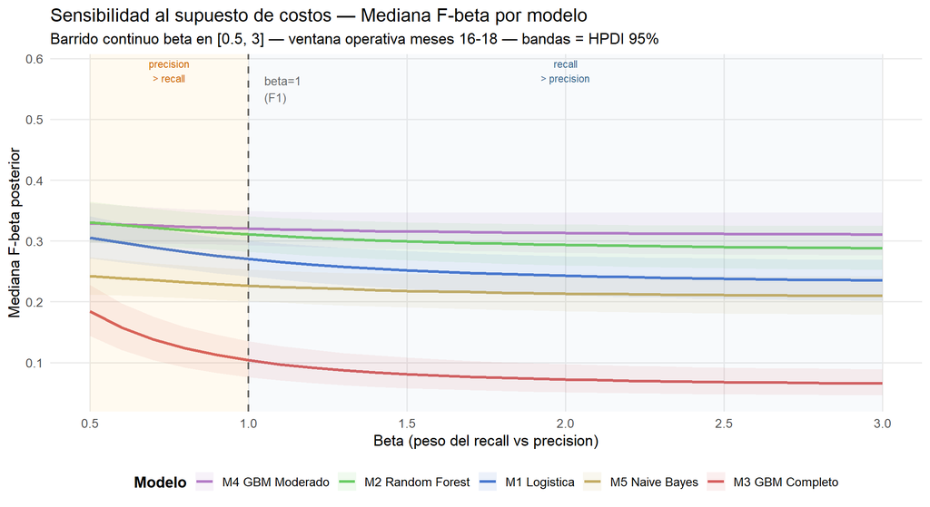

```r
# Usa muestras_p/r_lista, MODELOS, LABELS, COLORES y resumen_op — todos del Paso 6
betas_rango <- seq(0.5, 3, by = 0.1)

dt_barrido <- rbindlist(lapply(betas_rango, function(b) {
  rbindlist(lapply(MODELOS, function(mod) {
    fb <- f_beta(muestras_p_lista[[mod]], muestras_r_lista[[mod]], b)
    data.table(beta = b, modelo = mod, mediana = median(fb),
               lo = quantile(fb, 0.025), hi = quantile(fb, 0.975))
  }))
}))

dt_barrido[, modelo := factor(modelo, levels = resumen_op$Modelo)]

ggplot(dt_barrido, aes(x = beta, y = mediana, color = modelo, fill = modelo)) +
  geom_ribbon(aes(ymin = lo, ymax = hi), alpha = 0.10, color = NA) +
  geom_line(linewidth = 1.1) +
  geom_vline(xintercept = 1, linetype = "dashed",
             color = "gray40", linewidth = 0.8) +
  annotate("text", x = 1.05, y = 0.55, label = "beta=1\n(F1)",
           hjust = 0, size = 3.5, color = "gray40") +
  annotate("rect", xmin = 0.5, xmax = 1, ymin = -Inf, ymax = Inf,
           alpha = 0.06, fill = "orange") +
  annotate("text", x = 0.75, y = 0.58, label = "precision\n> recall",
           hjust = 0.5, size = 3, color = "darkorange3") +
  annotate("rect", xmin = 1, xmax = 3, ymin = -Inf, ymax = Inf,
           alpha = 0.04, fill = "steelblue") +
  annotate("text", x = 2, y = 0.58, label = "recall\n> precision",
           hjust = 0.5, size = 3, color = "steelblue4") +
  scale_color_manual(values = COLORES, labels = setNames(LABELS, MODELOS)) +
  scale_fill_manual(values  = COLORES, labels = setNames(LABELS, MODELOS)) +
  scale_x_continuous(breaks = seq(0.5, 3, by = 0.5)) +
  labs(
    title    = "Sensibilidad al supuesto de costos — Mediana F-beta por modelo",
    subtitle = "Barrido continuo beta en [0.5, 3] — ventana operativa meses 16-18 — bandas = HPDI 95%",
    x = "Beta (peso del recall vs precision)",
    y = "Mediana F-beta posterior",
    color = "Modelo", fill = "Modelo"
  ) +
  theme_minimal(base_size = 13) +
  theme(panel.grid.minor = element_blank(), legend.position = "bottom",
        legend.title = element_text(face = "bold"))
```

## 3 Recomendacion al APFLA en tres horizontes (a desarrollar)

### 3.1 Horizonte inmediato — julio 2025

**Accion:** reemplazar M3 por **M4 (GBM Moderado)** en produccion.

### 3.2 Horizonte corto plazo — agosto a octubre 2025

**Reentrenar M3** excluyendo `terminal_risk_score`, o recalibrarlo con el nuevo patron de terminales limpias comprometidas.

#### Alerta: señal de deterioro generalizado en meses 22-24

Los datos de los meses 22-24 (fase T2) revelan una señal critica:

```r
# Usa df_temp que ya existe del Paso 6 — no recarga el CSV
meses_clave <- df_temp[mes %in% c(16:24)]
meses_clave[, tp  := round(recall * n_fraude)]
meses_clave[, fn  := n_fraude - tp]
meses_clave[, fp  := ifelse(precision > 0, round((tp / precision) - tp), 0L)]
meses_clave[, f1p := round(2 * tp / (2 * tp + fp + fn), 3)]

tabla_t2 <- dcast(meses_clave[, .(modelo, mes, f1p)], modelo ~ mes,
                  value.var = "f1p")
setnames(tabla_t2, as.character(16:24),
         c("M16","M17","M18","M19","M20","M21","M22","M23","M24"))

tabla_t2 |>
  kable(
    caption   = "F1 puntual por modelo — meses 16 a 24",
    col.names = c("Modelo","16","17","18","19","20","21","22*","23*","24*")
  ) |>
  kable_styling(bootstrap_options = c("striped", "hover"), full_width = FALSE) |>
  add_header_above(c(" " = 1, "Ventana operativa" = 3,
                     "T1 extendido" = 3, "T2 — alerta (*)" = 3)) |>
  column_spec(8:10, background = "#fff3cd") |>
  footnote(general = "(*) Meses 22-24: expansion fuera del analisis principal.")
```

F1 puntual por modelo — meses 16 a 24

| Modelo | Ventana operativa 16 | Ventana operativa 17 | Ventana operativa 18 | T1 extendido 19 | T1 extendido 20 | T1 extendido 21 | T2 — alerta (*) 22* | T2 — alerta (*) 23* | T2 — alerta (*) 24* |
| --- | --- | --- | --- | --- | --- | --- | --- | --- | --- |
| M1_logistica | 0.309 | 0.268 | 0.236 | 0.320 | 0.287 | 0.277 | 0.139 | 0.071 | 0.046 |
| M2_random_forest | 0.326 | 0.309 | 0.298 | 0.347 | 0.336 | 0.357 | 0.194 | 0.106 | 0.056 |
| M3_gbm_completo | 0.177 | 0.102 | 0.029 | 0.009 | 0.009 | 0.000 | 0.031 | 0.008 | 0.009 |
| M4_gbm_moderado | 0.322 | 0.331 | 0.309 | 0.356 | 0.332 | 0.348 | 0.183 | 0.122 | 0.048 |
| M5_naive_bayes | 0.279 | 0.206 | 0.196 | 0.241 | 0.190 | 0.198 | 0.077 | 0.039 | 0.024 |

Note:  
(*) Meses 22-24: expansion fuera del analisis principal.

**Señal de alerta en T2:** a partir del mes 22 **todos los modelos** colapsan — no solo M3. El modelo con mayor caida es **M2_random_forest** con una perdida de 0.301 puntos entre el mes 21 y el 24. Esto sugiere una **segunda perturbacion del regimen** que compromete features de comportamiento transaccional (canal, dispositivo, secuencia) — las mismas que habian protegido a M1/M2/M4/M5 durante T1. **M4 podria ser vulnerable** si la campana evoluciona.